# Image classification

```python
## Import packages
import pandas as pd
import tensorflow as tf

from tensorflow.keras.models import Sequential
from tensorflow.keras.layers import Dense, Conv2D, Flatten, Dropout, MaxPooling2D, Activation, BatchNormalization
from tensorflow.keras.preprocessing.image import ImageDataGenerator

import os
import numpy as np
import matplotlib.pyplot as plt
```

For convenience, set up variables to use while pre-processing the dataset and training the network.

```python
batch_size = 16
epochs = 15

# Let's try with original image dimensions!
IMG_HEIGHT = 192
IMG_WIDTH = 192
```

## Data preparation

Format the images into appropriately pre-processed floating point tensors before feeding to the network:

1. Read images from the pandas dataframe, convinient to load directly from CSV on the fly.
2. Convert them into floating point tensors.
3. Rescale the tensors from values between 0 and 255 to values between 0 and 1, as neural networks prefer to deal with small input values.

Fortunately, all these tasks can be done with the `ImageDataGenerator` class provided by `tf.keras`. It can read images and preprocess them into proper tensors. It will also set up generators that convert these images into batches of tensors—helpful when training the network.

```python
# Generator for our training data
train_image_generator = ImageDataGenerator(rescale=1./255,)
                               #horizontal_flip=True,)
                               #rotation_range=45,)
                               #zoom_range=0.2,)
                               #width_shift_range=.15,)
                               #height_shift_range=.15)
validation_image_generator = ImageDataGenerator(rescale=1./255) # Generator for our validation data
```

After defining the generators for training and validation images, the `flow_from_dataframe` method load images directly from the csv, applies rescaling, and resizes the images into the required dimensions.

```python
image_dir = "../data/GrayImages"
train_data = pd.read_csv("../data/train.csv")
val_data = pd.read_csv("../data/test.csv")
total_train = len(train_data)
total_val = len(val_data)

train_data_gen = train_image_generator.flow_from_dataframe(train_data,
                                                            directory=image_dir,
                                                            x_col='IMAGE_FILENAME',
                                                            y_col=' LABEL',
                                                            target_size=(IMG_HEIGHT, IMG_WIDTH),
                                                            color_mode='grayscale',
                                                            class_mode='categorical',
                                                            batch_size=batch_size,
                                                            shuffle=True,
                                                            interpolation='nearest',
                                                            validate_filenames=True)
```

```
Found 640 validated image filenames belonging to 3 classes.
```

```python
val_data_gen = validation_image_generator.flow_from_dataframe(val_data,
                                                            directory=image_dir,
                                                            x_col='IMAGE_FILENAME',
                                                            y_col=' LABEL',
                                                            weight_col=None,
                                                            target_size=(IMG_HEIGHT, IMG_WIDTH),
                                                            color_mode='grayscale',
                                                            class_mode='categorical',
                                                            batch_size=batch_size,
                                                            shuffle=True,
                                                            interpolation='nearest',
                                                            validate_filenames=True)
```

```
Found 160 validated image filenames belonging to 3 classes.
```

### Visualize training images

Visualize the training images by extracting a batch of images from the training generator—which is 16 images in this example—then plot five of them with `matplotlib`.

```python
sample_training_images, labels = next(train_data_gen)
```

The `next` function returns a batch from the dataset. The return value of `next` function is in form of `(x_train, y_train)` where x_train is training features and y_train, its labels. Discard the labels to only visualize the training images.

```python
# This function will plot images in the form of a grid with 1 row and 5 columns where images are placed in each column.
def plotImages(images_arr):
    fig, axes = plt.subplots(1, 5, figsize=(20,20))
    axes = axes.flatten()
    for img, ax in zip( images_arr, axes):
        ax.imshow(img[:,:,0],  cmap=plt.cm.gray)
        ax.axis('off')

    plt.tight_layout()
    plt.show()
```

[figure not shown]

```python
plotImages(sample_training_images[:5])
```

## Create the model

The model consists of three convolution blocks with a max pool layer in each of them. There's a fully connected layer with 512 units on top of it that is activated by a `relu`` activation function.

```python
model = Sequential([
    Conv2D(16, 3, padding='same', activation='relu',
           input_shape=(IMG_HEIGHT, IMG_WIDTH ,1)),
    MaxPooling2D(),
    Dropout(0.2),
    Conv2D(32, 3, padding='same', activation='relu'),
    MaxPooling2D(),
    Conv2D(64, 3, padding='same', activation='relu'),
    MaxPooling2D(),
    Dropout(0.2),
    Flatten(),
    Dense(512, activation='relu'),
    Dense(3)
])
```

```
WARNING:tensorflow:From /home/aadmin/MyProjects/ML-Challenge-Revolut/Challenge_Solution/env/lib/python3.7/site-packages/tensorflow_core/python/ops/resource_variable_ops.py:1630: calling BaseResourceVariable.__init__ (from tensorflow.python.ops.resource_variable_ops) with constraint is deprecated and…
Instructions for updating:
If using Keras pass *_constraint arguments to layers.
```

### Compile the model

```python
model.compile(optimizer='adam',
              loss=tf.keras.losses.categorical_crossentropy,
              metrics=['accuracy'])
```

### Model summary

View all the layers of the network using the model's `summary` method:

```python
model.summary()
```

```
Model: "sequential"
_________________________________________________________________
Layer (type)                 Output Shape              Param #
=================================================================
conv2d (Conv2D)              (None, 192, 192, 16)      160
_________________________________________________________________
max_pooling2d (MaxPooling2D) (None, 96, 96, 16)        0
_________________________________________________________________
dropout (Dropout)            (None, 96, 96, 16)        0
_________________________________________________________________
conv2d_1 (Conv2D)            (None, 96, 96, 32)        4640
_________________________________________________________________
max_pooling2d_1 (MaxPooling2 (None, 48, 48, 32)        0
_________________________________________________________________
conv2d_2 (Conv2D)            (None, 48, 48, 64)        18496
_________________________________________________________________
max_pooling2d_2 (MaxPooling2 (None, 24, 24, 64)        0
_________________________________________________________________
dropout_1 (Dropout)          (None, 24, 24, 64)        0
_________________________________________________________________
flatten (Flatten)            (None, 36864)             0
_________________________________________________________________
dense (Dense)                (None, 512)               18874880
_________________________________________________________________
dense_1 (Dense)              (None, 3)                 1539
=================================================================
Total params: 18,899,715
Trainable params: 18,899,715
Non-trainable params: 0
_________________________________________________________________
```

### Train the model

Use the `fit_generator` method of the `ImageDataGenerator` class to train the network.

```python
history = model.fit_generator(
    train_data_gen,
    steps_per_epoch=total_train // batch_size,
    epochs=epochs,
    validation_data=val_data_gen,
    validation_steps=total_val // batch_size
)
```

```
WARNING:tensorflow:From /home/aadmin/MyProjects/ML-Challenge-Revolut/Challenge_Solution/env/lib/python3.7/site-packages/tensorflow_core/python/ops/math_grad.py:1424: where (from tensorflow.python.ops.array_ops) is deprecated and will be removed in a future version.
Instructions for updating:
Use tf.where in 2.0, which has the same broadcast rule as np.where
```

### Visualize training results

Now visualize the results after training the network.

[figure not shown]

```python
acc = history.history['acc']
val_acc = history.history['val_acc']

loss=history.history['loss']
val_loss=history.history['val_loss']

epochs_range = range(epochs)

plt.figure(figsize=(8, 8))
plt.subplot(1, 2, 1)
plt.plot(epochs_range, acc, label='Training Accuracy')
plt.plot(epochs_range, val_acc, label='Validation Accuracy')
plt.legend(loc='lower right')
plt.title('Training and Validation Accuracy')

plt.subplot(1, 2, 2)
plt.plot(epochs_range, loss, label='Training Loss')
plt.plot(epochs_range, val_loss, label='Validation Loss')
plt.legend(loc='upper right')
plt.title('Training and Validation Loss')
plt.show()
```

### The model is not looking great at the moment, let's do some tweeking to it to further improve the results

[output not shown]

[figure not shown]

```python
new_model = Sequential()
new_model.add(Conv2D(32, (3, 3), padding='same',
                 input_shape=(IMG_HEIGHT,IMG_WIDTH,1)))
new_model.add(Activation('relu'))
new_model.add(Conv2D(32, (3, 3)))
new_model.add(Activation('relu'))
new_model.add(MaxPooling2D(pool_size=(2, 2)))
new_model.add(Dropout(0.25))

new_model.add(Conv2D(64, (3, 3), padding='same'))
new_model.add(Activation('relu'))
new_model.add(Conv2D(64, (3, 3)))
new_model.add(Activation('relu'))
new_model.add(MaxPooling2D(pool_size=(2, 2)))
new_model.add(Dropout(0.25))

new_model.add(Flatten())
new_model.add(Dense(512))
new_model.add(Activation('relu'))
new_model.add(Dropout(0.5))
new_model.add(Dense(3, activation='softmax'))

#Compile the model
new_model.compile(optimizer='adam',
              loss=tf.keras.losses.categorical_crossentropy,
              metrics=['accuracy'])

#Collect Relevant History
history = new_model.fit_generator(
    train_data_gen,
    steps_per_epoch=total_train // batch_size,
    epochs=epochs,
    validation_data=val_data_gen,
    validation_steps=total_val // batch_size
)

acc = history.history['acc']
val_acc = history.history['val_acc']

loss=history.history['loss']
val_loss=history.history['val_loss']

epochs_range = range(epochs)

plt.figure(figsize=(8, 8))
plt.subplot(1, 2, 1)
plt.plot(epochs_range, acc, label='Training Accuracy')
plt.plot(epochs_range, val_acc, label='Validation Accuracy')
plt.legend(loc='lower right')
plt.title('Training and Validation Accuracy')

plt.subplot(1, 2, 2)
plt.plot(epochs_range, loss, label='Training Loss')
plt.plot(epochs_range, val_loss, label='Validation Loss')
plt.legend(loc='upper right')
plt.title('Training and Validation Loss')
plt.show()
```

#### The model is too big and Overfitting let's try to remove few layers and add normalization layers

[output not shown]

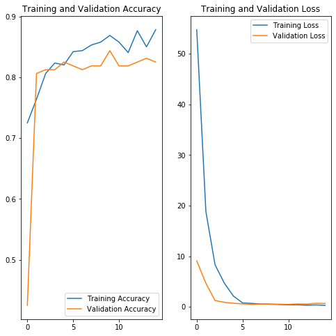

```python
new_model = Sequential()
new_model.add(Conv2D(16, (3, 3), padding='same',
                 input_shape=(IMG_HEIGHT,IMG_WIDTH,1)))
new_model.add(Activation('relu'))
new_model.add(Conv2D(32, (3, 3)))
new_model.add(BatchNormalization())
new_model.add(Activation('relu'))
new_model.add(MaxPooling2D(pool_size=(2, 2)))
new_model.add(Dropout(0.25))


new_model.add(Conv2D(64, (3, 3)))
new_model.add(BatchNormalization())
new_model.add(Activation('relu'))
new_model.add(MaxPooling2D(pool_size=(2, 2)))
new_model.add(Dropout(0.25))

new_model.add(Flatten())
new_model.add(Dense(512))
new_model.add(Activation('relu'))
new_model.add(Dropout(0.5))
new_model.add(Dense(3, activation='softmax'))

#Compile the model
new_model.compile(optimizer='adam',
              loss=tf.keras.losses.categorical_crossentropy,
              metrics=['accuracy'])

#Collect Relevant History
history = new_model.fit_generator(
    train_data_gen,
    steps_per_epoch=total_train // batch_size,
    epochs=epochs,
    validation_data=val_data_gen,
    validation_steps=total_val // batch_size
)

acc = history.history['acc']
val_acc = history.history['val_acc']

loss=history.history['loss']
val_loss=history.history['val_loss']

epochs_range = range(epochs)

plt.figure(figsize=(8, 8))
plt.subplot(1, 2, 1)
plt.plot(epochs_range, acc, label='Training Accuracy')
plt.plot(epochs_range, val_acc, label='Validation Accuracy')
plt.legend(loc='lower right')
plt.title('Training and Validation Accuracy')

plt.subplot(1, 2, 2)
plt.plot(epochs_range, loss, label='Training Loss')
plt.plot(epochs_range, val_loss, label='Validation Loss')
plt.legend(loc='upper right')
plt.title('Training and Validation Loss')
plt.show()
```

### This looks better, let's Save the Model

```python
# Let's save this model now
tf.keras.models.save_model(new_model,"../artifacts/Exp_1")
```

## Model Loading and Testing

```python
#del(new_model)
#del(loaded_model)
loaded_model = tf.keras.models.load_model("../artifacts/Experiment_1")
loaded_model.summary()
```

[output not shown]

```python
test_set = next(val_data_gen)
images, labels = test_set
#Evaluate the performance of our model
loss, acc = loaded_model.evaluate(images, labels, verbose=2)
print('Restored model, Batch accuracy: {:5.2f}%'.format(100*acc))
print(images.shape)
result = loaded_model.predict(images)
```

```
16/16 - 1s - loss: 0.2848 - acc: 0.8750
Restored model, Batch accuracy: 87.50%
(16, 192, 192, 1)
```

### Let's do some plotting of results and also show model confidence

```python
#Define Class names for mapping the indexes
class_names = ['Full_visibility',  'no_visibility', 'partial_visibility']

def plot_image(i, predictions_array, true_label, img):
    predictions_array, true_label, img = predictions_array, np.argmax(true_label[i]), img[i]
    plt.grid(False)
    plt.xticks([])
    plt.yticks([])

    plt.imshow(img[:,:,0], cmap=plt.cm.binary) # Just checking how images will look in binary color mode

    predicted_label = np.argmax(predictions_array)

    #Coorect predictions will be in blue and wrong ones in red
    if predicted_label == true_label:
        color = 'blue'
    else:
        color = 'red'

    plt.xlabel("{} {:2.0f}% ({})".format(class_names[predicted_label],
                                100*np.max(predictions_array),
                                class_names[true_label]),
                                color=color)

#Plot the bar chart
def plot_value_array(i, predictions_array, true_label):
    predictions_array, true_label = predictions_array, np.argmax(true_label[i])
    plt.grid(False)
    plt.xticks(range(3))
    plt.yticks([])
    thisplot = plt.bar(range(3), predictions_array, color="#777777")
    plt.ylim([0, 1])
    predicted_label = np.argmax(predictions_array)

    thisplot[predicted_label].set_color('red')
    thisplot[true_label].set_color('blue')
```

[figure not shown]

```python
# Testing the plot for single image
i = 0
plt.figure(figsize=(6,3))
plt.subplot(1,2,1)
plot_image(i, result[i], labels, images)
plt.subplot(1,2,2)
plot_value_array(i, result[i],  labels)
plt.show()
```

[figure not shown]

```python
# Plot the first X test images from the batch, and their predicted labels, and the true labels.
# Color correct predictions in blue and incorrect predictions in red.
num_rows = 5
num_cols = 3
num_images = num_rows*num_cols
plt.figure(figsize=(2*2*num_cols, 2*num_rows))
for i in range(num_images):
  plt.subplot(num_rows, 2*num_cols, 2*i+1)
  plot_image(i, result[i], labels, images)
  plt.subplot(num_rows, 2*num_cols, 2*i+2)
  plot_value_array(i, result[i],  labels)
plt.tight_layout()
plt.show()
```